# FinalProject

Megan Willis-Jackson

10/13/2020

# Cost of Housing in Massachusetts

## Introduction

This research question is important to understand how various factors impact how much a person will spend on housing. It will be interesting to theorize about tradeoffs that may or may not be supported by the data, for example if a person makes a choice to take a longer commute in order to pay less in rent, or if they will pay more to be within walking distance of their job as opposed to needing to drive.

### Hypothesis

The hypothesis that I will test is that the shorter an MA resident’s commute, the more they pay in rent. I will also test the hypothesis that people who commute via driving tend to pay less in rent than those who use other modes. I will test whether there is a positive correlation between monthly income and housing costs, as well as whether any relationship exists between educational attainment and housing costs.

## Data

My dataset is drawn from the 2018 ACS and includes all MA residents who a) make more than $0 in monthly income, b) pay more than $0 in monthly housing costs, and c) commute longer than 0 minutes to work.

### Data Transformations

My analysis includes the five variables listed above. The housing price variable is a combination of three variables within ACS: rent, first mortgage, and second mortgage. Each individual in the dataset pays either a rent or a mortgage, and those who pay a first mortgage may also pay a second mortgage. Therefore, this variable may be correlated with real estate value, but is a bit more nuanced because a person living in a home worth a certain amount of money may pay less per month than another person living in a home worth less money because the latter may pay a mortgage and a second mortgage, for example.

Education attainment is provided in the ACS as over twenty levels. I have further binned these categories into “High School or Lower,” and “Post-High School,” as I anticipated this would be the most meaningful divide in terms of differences between the two populations.

### Variable Summary Statistics

Summary statistics for the variables are included below to provide a clearer picture of the sample being examined.

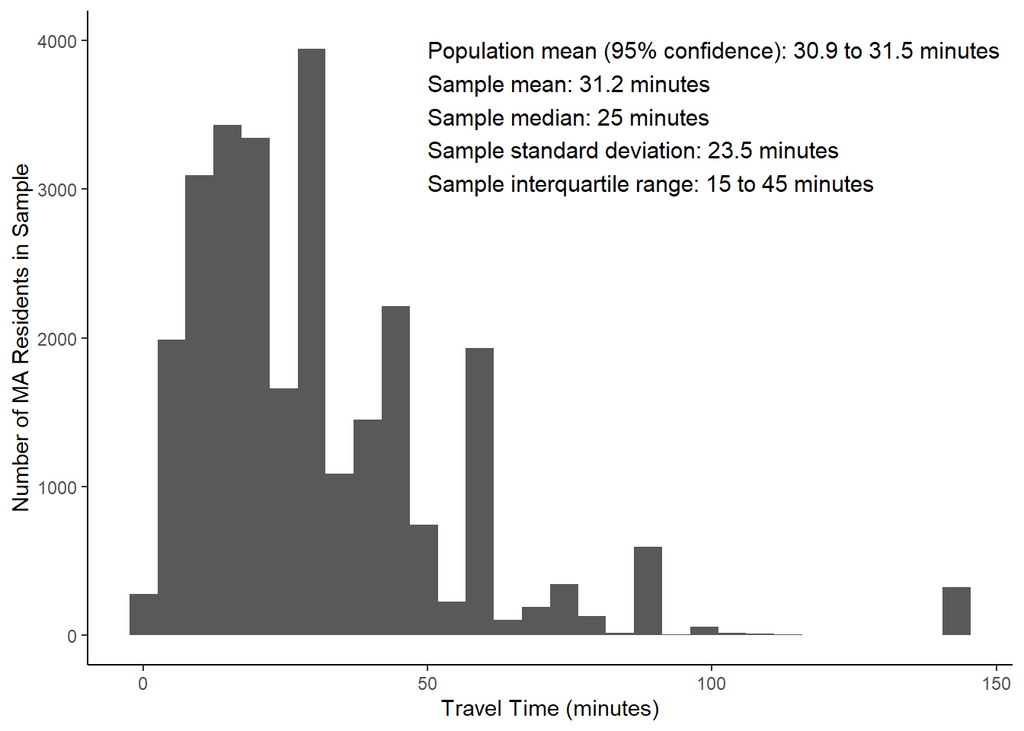

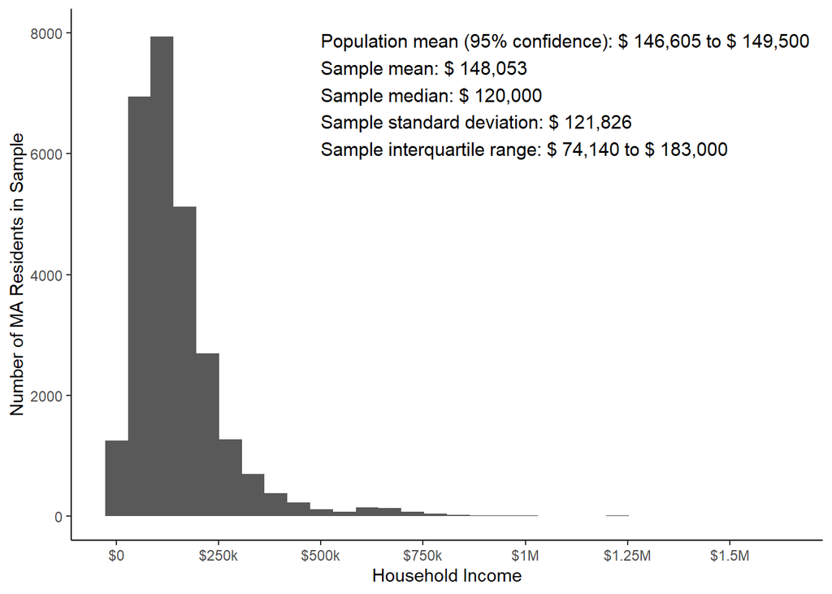

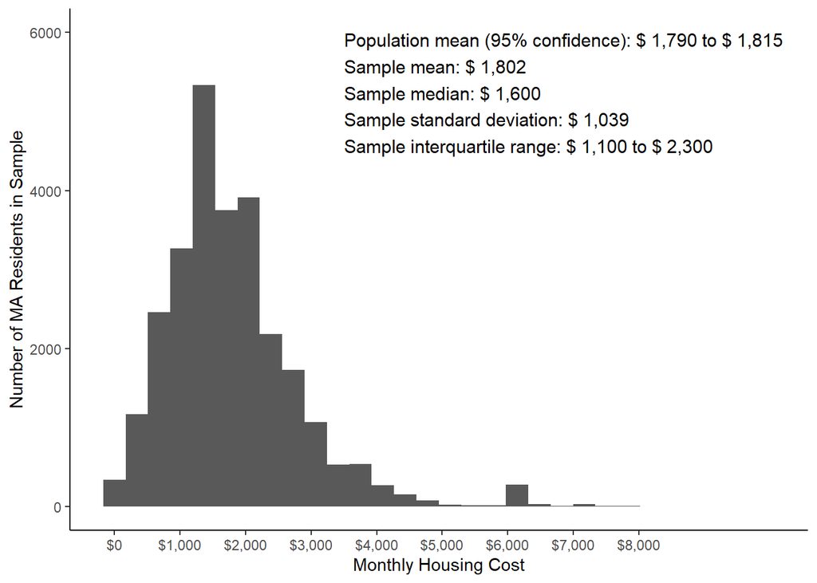

```
##  [1] "Car, truck, or van"
##  [2] "Subway or elevated"
##  [3] "Walked"
##  [4] "Railroad"
##  [5] "Bus or trolley bus"
##  [6] "Streetcar or trolley car (carro publico in Puerto Rico)"
##  [7] "Bicycle"
##  [8] "Other method"
##  [9] "Taxicab"
## [10] "Ferryboat"
## [11] "Motorcycle"
```

[output not shown]

## Highest Level of Education

[output not shown]

[figure not shown]

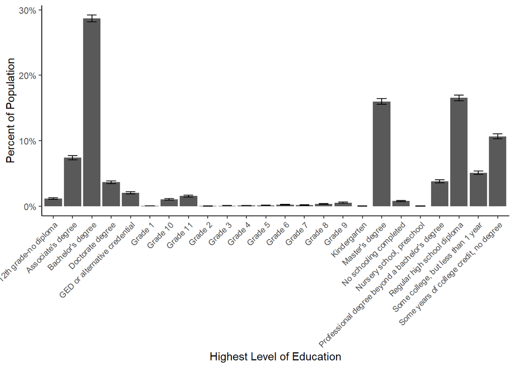

## Methods

I used a variety of statistical tests to explore my hypothesis. These tests included two sample t-tests, correlations, chi-square tests, and linear regressions. For each test, a p-value of less than 0.05 indicated a relationship at the 95% confidence level, which I took as strong enough evidence that I should not reject my alternative hypothesis. The linear regression model analyzes the data hollistically as opposed to relationships between just two variables, so this is likely the most useful model to predict relationships between my selected variables. As each of the t-tests and correlations I examined yielded a p-value of less than 0.05, I feel it is appropriate to include each of them in the linear regression. Below, I present some of the t-tests and the linear regression I performed to paint a picture of housing prices in MA.

### Relationship between Monthly Housing Cost and Level of Education

[output not shown]

[figure not shown]

We can be 95% confident that MA residents with some form of higher education pay, on average, between $503 to $549 more per month for housing than MA residents without any form of higher education.

```
##
##  Welch Two Sample t-test
##
## data:  monthly_housing_total by education_binary == "Post HS"
## t = -44.375, df = 20517, p-value < 2.2e-16
## alternative hypothesis: true difference in means is not equal to 0
## 95 percent confidence interval:
##  -549.2346 -502.7666
## sample estimates:
## mean in group FALSE  mean in group TRUE
##            1432.824            1958.824
```

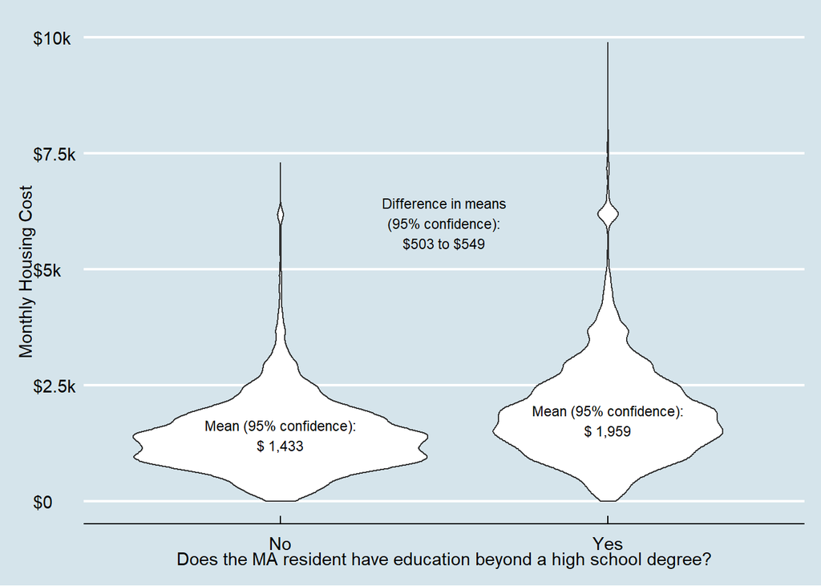

### Linear Regression

Below I present the results of my linear regression. This model seeks to predict the relationship between monthly housing costs and mode of commute, level of educational attainment, household income, and travel time. It additionally examines how the interaction between mode of commute and travel time may affect housing costs, because I think there may be an interaction between people’s travel time and mode of commute; for example, it intuitively would be much rarer for a person to choose to walk to work for 1.5 hours if they had an option of driving for 30 minutes. In this regression, mode of commute is binned into four categories which includes driving as the base case (car, truck, or van; taxi; or motorcycle); public transit; walking/biking; and other.

To me, this interaction is really quite interesting. While the regression results of the transportation mode variable without the interaction indicate at the 95% confidence level that people using each of the modes of transportation (walk/bike, public transit, and other) pay a couple of hundred dollars more in housing costs per month than a person who drives (all else being equal), as travel time increases, the average person pays more if they drive a car whereas their monthly housing costs decrease if they use any of the other mode categories.

This model has an R-squared value of 0.249, meaning it explains almost 25% of the variances in monthly housing costs for MA residents.

The model also suggests that:

1. A person with an education above a high school degree pays about $276 more in housing costs than a person with no education above a high school degree, all else being equal.
2. For every minute increase in time spent commuting, an MA resident pays about $2.26 more in housing costs, all else being equal.
3. The longer a person commutes using a mode other than driving, the less they tend to pay in housing costs, all else equal.
4. And, contrary to what number 3 may suggest, using a mode other than driving to commute predicts that a person will pay more in housing costs, all else being equal.

```
##
## Call:
## lm(formula = monthly_housing_total ~ transpo_categories + education_binary +
##     household_income + travel_time + transpo_categories:travel_time,
##     data = people_mutated)
##
## Residuals:
##     Min      1Q  Median      3Q     Max
## -5901.4  -525.8   -90.1   412.0  6281.3
##
## Coefficients:
##                                                  Estimate   Std. Error t value
## (Intercept)                                  940.69819045  13.32897896  70.575
## transpo_categoriesother                      249.51034917  82.34040670   3.030
## transpo_categoriespublic transit             390.94399081  36.29843299  10.770
## transpo_categorieswalk/bike                  368.58959790  37.27263700   9.889
## education_binaryPost HS                      276.80892452  12.33261024  22.445
## household_income                               0.00376374   0.00004611  81.633
## travel_time                                    2.25725015   0.27232764   8.289
## transpo_categoriesother:travel_time           -4.46446500   1.53165145  -2.915
## transpo_categoriespublic transit:travel_time  -3.96963477   0.68726488  -5.776
## transpo_categorieswalk/bike:travel_time       -4.52630546   1.57405636  -2.876
##                                                          Pr(>|t|)
## (Intercept)                                  < 0.0000000000000002 ***
## transpo_categoriesother                                   0.00245 **
## transpo_categoriespublic transit             < 0.0000000000000002 ***
## transpo_categorieswalk/bike                  < 0.0000000000000002 ***
## education_binaryPost HS                      < 0.0000000000000002 ***
## household_income                             < 0.0000000000000002 ***
## travel_time                                  < 0.0000000000000002 ***
## transpo_categoriesother:travel_time                       0.00356 **
## transpo_categoriespublic transit:travel_time        0.00000000773 ***
## transpo_categorieswalk/bike:travel_time                   0.00404 **
## ---
## Signif. codes:  0 '***' 0.001 '**' 0.01 '*' 0.05 '.' 0.1 ' ' 1
##
## Residual standard error: 900.2 on 27217 degrees of freedom
## Multiple R-squared:  0.2492, Adjusted R-squared:  0.249
## F-statistic:  1004 on 9 and 27217 DF,  p-value: < 0.00000000000000022
```

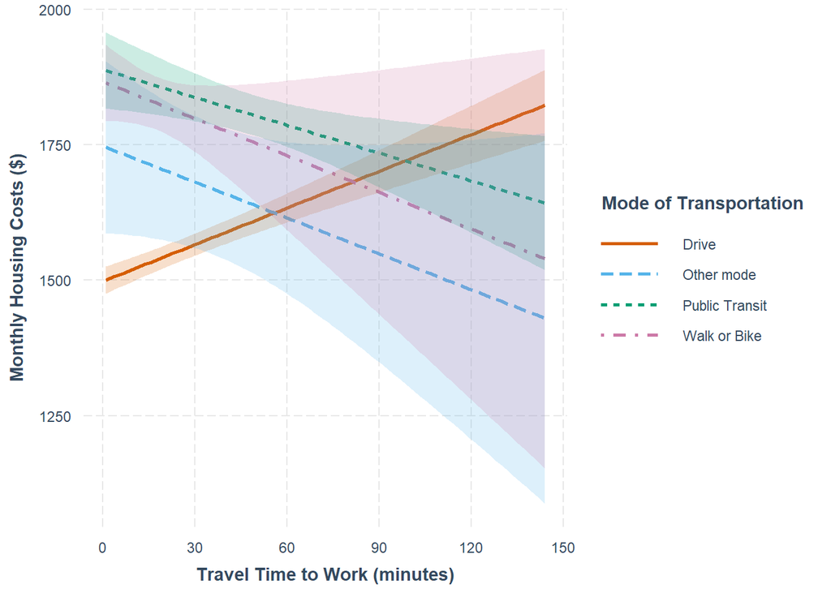

## Discussion

To restate my initial hypothesis, I was testing whether the shorter an MA resident’s commute, the more they pay in rent; people who commute via driving tend to pay less in rent than those who use other modes; and whether there is a positive correlation between monthly income and housing costs, as well as whether any relationship exists between educational attainment and housing costs.

The results of my linear regression suggest that there is a positive correlation between travel time and housing costs. For each additional minute spent commuting, an MA resident will pay on average an additional $2.26 in housing costs, holding all else equal, which does not support my hypothesis. That result is significant at the 95% confidence interval. The results of the linear regression do support the hypothesis that MA residents who drive tend to pay less in rent than those who use other modes (all else being equal), which we can say with 95% confidence. Of note, however, is that when examining the interaction between travel time and travel mode, each minute longer spent commuting tends to decrease the amount spent on housing for all modes except for driving, which increases. This suggests that, in the context of Massachusetts, residents living farther from their jobs who drive choose to pay more to live farther away; perhaps access to the larger, more expansive real estate farther from the city is the cause.

If I were to investigate this further, I would like to add in a variable on urban, suburban, and rural housing to control for that (assuming real estate tends to be more expensive in the city), as well as distance from one’s job, not just time spent commuting. The most glaring weakness in this analysis is the low number of variables it includes. There are so many variables which likely have an effect on housing costs; to figure out how to best improve my analysis, I would conduct background research on what these variables are.

## Conclusion

This analysis is important because, as urban planners intending to improve the lives of people in a variety of communities, it is beneficial to know how the factors examined here interact with each other given that they have a relatively big impact on quality of life. Is there an ideal trade-off between time spent commuting and housing costs? Would a person appreciate less time spent in traffic if they were able to walk? Time and money are arguably two of the biggest things weighing on people’s minds as they make decisions in their lives, so having an indication of what the trade-offs between them are serve to help urban planners make decisions within their communities.